# Creating FFTs with fft()

Nathaniel Phillips

2016-08-16

This function is at the heart of the `FFTrees` package. The function takes a training dataset as an argument, and generates several FFT (more details about the algorithms coming soon…)

## heartdisease example

```r
head(heartdisease)
```

```
##   age sex cp trestbps chol fbs     restecg thalach exang oldpeak slope ca
## 1  63   1 ta      145  233   1 hypertrophy     150     0     2.3  down  0
## 2  67   1  a      160  286   0 hypertrophy     108     1     1.5  flat  3
## 3  67   1  a      120  229   0 hypertrophy     129     1     2.6  flat  2
## 4  37   1 np      130  250   0      normal     187     0     3.5  down  0
## 5  41   0 aa      130  204   0 hypertrophy     172     0     1.4    up  0
## 6  56   1 aa      120  236   0      normal     178     0     0.8    up  0
##     thal diagnosis
## 1     fd         0
## 2 normal         1
## 3     rd         1
## 4 normal         0
## 5 normal         0
## 6 normal         0
```

The critical dependent variable is `diagnosis` which indicates whether a patient has heart diesease or not. The other variables in the dataset (e.g.; sex, age, and several biological measurements) will be used as predictors.

Now we’ll split the original dataset into a *training* dataset, and a *testing* dataset. We will create the trees with the training set, then test its performance in the test dataset:

```r
set.seed(100)
samples <- sample(c(T, F), size = nrow(heartdisease), replace = T)
heartdisease.train <- heartdisease[samples,]
heartdisease.test <- heartdisease[samples == 0,]
```

We’ll create a new fft object called `heart.fft` using the `fft()` function. We’ll specify `diagnosis` as the (binary) dependent variable, and include all independent varaibles with `formula = diagnosis ~ .`:

```r
heart.fft <- fft(
  formula = diagnosis ~.,
  data = heartdisease.train,
  data.test = heartdisease.test
  )
```

## Elements of an fft object

As you can see, `fft()` returns an object with the fft class

```r
class(heart.fft)
```

```
## [1] "fft"
```

There are many elements in an fft object, here are their names:

```r
names(heart.fft)
```

```
##  [1] "formula"        "data.train"     "data.test"      "cue.accuracies"
##  [5] "fft.stats"      "lr.stats"       "cart.stats"     "auc"
##  [9] "lr.model"       "cart.model"     "decision.train" "decision.test"
## [13] "levelout.train" "levelout.test"
```

## Printing an fft object

You can view basic information about the fft object by printing its name. This will give you a quick summary of the object, includeing how many trees it has, which cues the tree(s) use, and how well they performed.

```r
heart.fft
```

```
## [1] "An fft object containing 8 trees using 4 cues {thal,cp,exang,slope} out of an original 13"
## [1] "Data were trained on 149 exemplars, and tested on 154 new exemplars"
## [1] "FFT AUC: (Train = 0.88, Test = 0.85)"
## [1] "My favorite tree is #5 [Training: HR = 0.91, FAR = 0.24], [Testing: HR = 0.79, FAR = 0.25]"
```

### Cue accuracy statistics: cue.accuracies

You can obtain marginal cue accuracy statistics from the `cue.accuracies` dataframe. This dataframe contains the original, marginal cue accuracies. That is, for each cue, the threshold that maximizes the v-statistic (HR - FAR) is chosen.

```r
heart.fft$cue.accuracies
```

```
##    cue.name cue.class      level.threshold level.sigdirection hi.train
## 1       age   numeric                53.89                 >=       43
## 2        ca   numeric                    0                  >       41
## 3      chol   numeric               252.32                  >       36
## 4        cp character             np,aa,ta                 !=       50
## 5     exang   numeric                    1                 >=       40
## 6       fbs   numeric                    0                  >       12
## 7   oldpeak   numeric                 0.98                  >       42
## 8   restecg character hypertrophy,abnormal                  =       39
## 9       sex   numeric                    1                 >=       51
## 10    slope character                   up                 !=       52
## 11     thal character               normal                 !=       47
## 12  thalach   numeric               144.32                 <=       36
## 13 trestbps   numeric               138.74                  >       27
##    mi.train fa.train cr.train hr.train far.train    v.train dprime.train
```

[output cut: 41 more lines]

You can also view the cue accuracies in an ROC-type plot with `showcues()`:

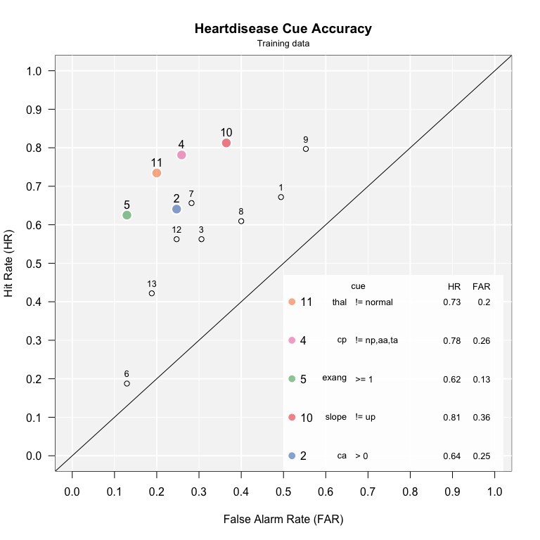

```r
showcues(heart.fft,
         main = "Heartdisease Cue Accuracy")
```

### Tree definitions and accuracy statistics: fft.stats

The `fft.stats` dataframe contains all tree definitions and training (and possibly test) statistics for all ($2^{max.levels - 1}$) trees. For our `heart.fft` example, there are $2^{4 - 1} = 8$ trees.

```r
heart.fft$fft.stats
```

```
##   tree.num          level.name                           level.class
## 1        1 thal;cp;exang;slope character;character;numeric;character
## 5        2       thal;cp;exang           character;character;numeric
## 3        3       thal;cp;exang           character;character;numeric
## 7        4 thal;cp;exang;slope character;character;numeric;character
## 2        5       thal;cp;exang           character;character;numeric
## 6        6 thal;cp;exang;slope character;character;numeric;character
## 4        7       thal;cp;exang           character;character;numeric
## 8        8 thal;cp;exang;slope character;character;numeric;character
##   level.exit level.threshold level.sigdirection n.train hi.train mi.train
## 1  0;0;0;0.5   normal;a;0;up          !=;=;>;!=     149       22       42
## 5    0;0;0.5      normal;a;0             !=;=;>     149       26       38
## 3    0;1;0.5      normal;a;0             !=;=;>     149       39       25
## 7  0;1;1;0.5   normal;a;0;up          !=;=;>;!=     149       46       18
## 2    1;0;0.5      normal;a;0             !=;=;>     149       58        6
```

[output cut: 30 more lines]

You can also use the generic `summary()` function to get the trees dataframe

```r
summary(heart.fft)  # Same thing as heart.fft$fft.stats
```

### Area under the curve (AUC): auc

AUC (area under the curve) statistics are in the `auc` dataframe:

```r
heart.fft$auc
```

```
##             fft        lr      cart
## train 0.8848346 0.8611213 0.8533088
## test  0.8462447 0.7973840 0.7390717
```

### Other information

#### train.decision.df, test.decision.df

The `train.decision.df` and `test.decision.df` contain the raw classification decisions for each tree for each training (and test) case.

Here are each of the 8 tree decisions for the first 5 training cases.

```r
heart.fft$decision.train[1:5,]
```

```
##   tree.1 tree.2 tree.3 tree.4 tree.5 tree.6 tree.7 tree.8
## 1      0      0      0      1      1      1      1      1
## 2      0      0      0      0      1      1      1      1
## 3      0      0      0      0      0      0      0      1
## 4      0      0      0      0      0      0      0      0
## 5      0      0      0      0      0      0      0      0
```

#### train.levelout.df, test.levelout.df

The `train.levelout.df` and `test.levelout.df` contain the levels at which each case was classified for each tree.

Here are the levels at which the first 5 training cases were classified:

```r
heart.fft$levelout.train[1:5,]
```

```
##   tree.1 tree.2 tree.3 tree.4 tree.5 tree.6 tree.7 tree.8
## 1      2      2      3      4      1      1      1      1
## 2      1      1      1      1      3      3      2      2
## 3      1      1      1      1      2      2      3      4
## 4      1      1      1      1      2      2      3      4
## 5      1      1      1      1      2      2      3      4
```

## Selecting cues

If you want to select specific cues for a tree, just include them in the `formula` argument.

For example, the following tree `heart.as.fft` will only consider the cues `sex` and `age`:

```r
heart.as.fft <- fft(formula = diagnosis ~ age + sex,
                    data = heartdisease
                    )
```

## Plotting trees

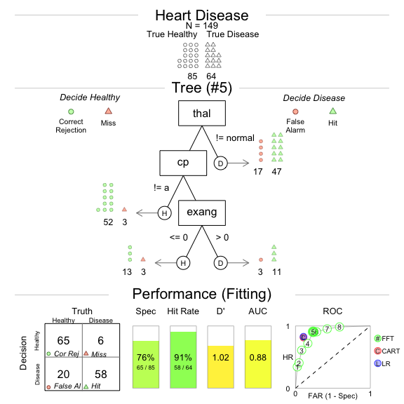

```r
plot(heart.fft,
     main = "Heart Disease",
     decision.names = c("Healthy", "Disease")
     )
```

See the vignette on `plot.fft` `vignette("fft_plot", package = "fft")` for more details.

## Additional arguments

The `fft()` function has several additional arguments than change how trees are built. Note: Not all of these arguments have fully tested yet!

- `train.p`: What percent of the data should be used for training? `train.p = .1` will randomly select 10% of the data for training and leave the remaining 90% for testing. Settting `train.p = 1` will fit the trees to the entire dataset (with no testing).
- `rank.method`: As trees are being built, should cues be selected based on their marginal accuracy (`rank.method = "m"`) applied to the entire dataset, or on their conditional accuracy (`rank.method = "c"`) applied to all cases that have not yet been classified? Each method has potential pros and cons. The marginal method is much faster to implement and may be prone to less over-fitting. However, the conditional method could capture important conditional dependencies between cues that the marginal method misses.